# Section 5: Machine Learning

Chen Lianghe

2022-06-30

```r
knitr::opts_chunk$set(echo = TRUE)
```

## Overview

Using the dataset from https://archive.ics.uci.edu/ml/datasets/Car+Evaluation, create a machine learning model to predict the buying price of a car given the following parameters:

1. Maintenance = High
2. Number of Doors = 4
3. Lug Boot Size = Big
4. Safety = High
5. Class Value = Good

## Loading of Libraries

```r
# Loading of Libraries
library(caret)
```

```r
library(RColorBrewer)
library(corrplot)
library(rpart)
library(rpart.plot)
library(rattle)
library(randomForest)
library(gbm)
library(stringr)
library(latex2exp)
```

## Loading and Cleaning of Data

```r
# Loading the Data
train_in <- read.csv('./car_train.csv', header=T)
test_in <- read.csv('./car_test.csv', header=T)

train_in[c('buying_price', 'maintenance', 'no_of_doors', 'capacity_persons', 'lug_boot_size', 'safety', 'class')] <- str_split_fixed(train_in$car_train, ',', 7)
train_in <- train_in[c('buying_price', 'maintenance', 'no_of_doors', 'capacity_persons', 'lug_boot_size', 'safety', 'class')]

test_in[c('buying_price', 'maintenance', 'no_of_doors', 'capacity_persons', 'lug_boot_size', 'safety', 'class')] <- str_split_fixed(test_in$car_test, ',', 7)
test_in <- test_in[c('buying_price', 'maintenance', 'no_of_doors', 'capacity_persons', 'lug_boot_size', 'safety', 'class')]

dim(train_in)
```

```
## [1] 1728    7
```

```r
dim(test_in)
```

```
## [1] 1 7
```

```r
# Cleaning the Data
trainData <- train_in[, colSums(is.na(train_in)) == 0]
testData <- test_in[, colSums(is.na(test_in)) == 0]

dim(trainData)
```

```
## [1] 1728    7
```

```r
dim(testData)
```

```
## [1] 1 7
```

## Preparing Datasets for Prediction

```r
# Splitting the Training Data
set.seed(1234)
inTrain <- createDataPartition(trainData$buying_price, p = 0.5, list = FALSE)
trainData <- trainData[inTrain, ]
validData <- trainData[-inTrain, ]

dim(trainData)
```

```
## [1] 864   7
```

```r
dim(validData)
```

```
## [1] 432   7
```

```r
trainData <- as.data.frame(lapply(trainData, as.numeric))
validData <- as.data.frame(lapply(validData, as.numeric))
```

## Plotting a Correlation Plot for Training Data

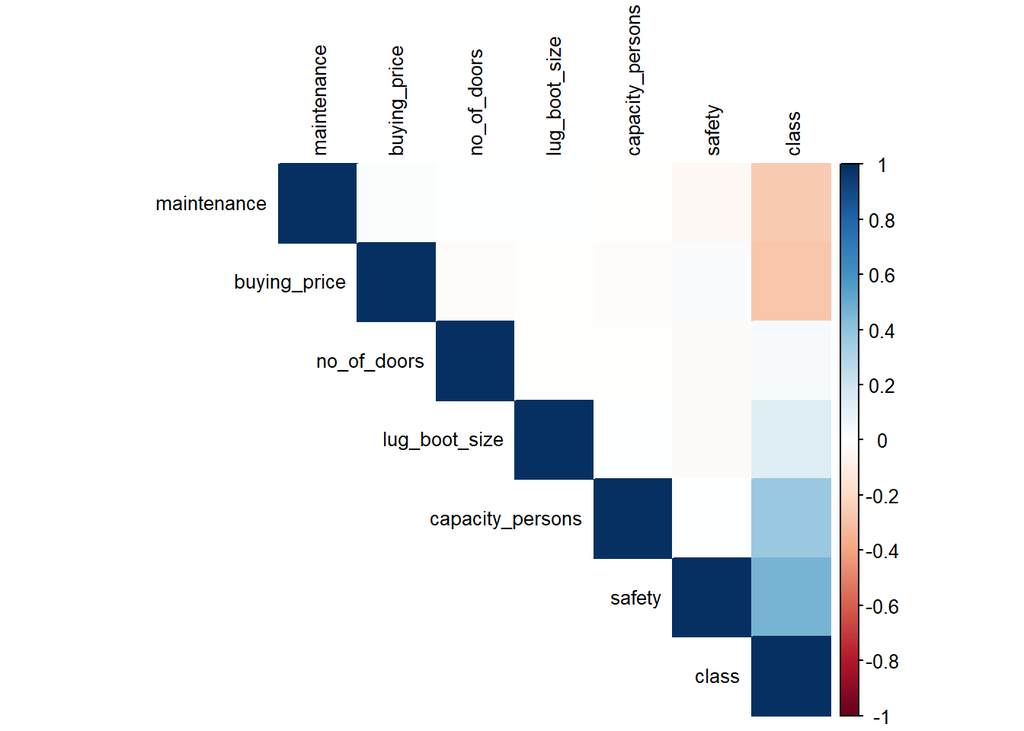

```r
# Plotting a Correlation Plot for Training Data
cor_mat <- cor(trainData)
corrplot(cor_mat, order = "FPC", method = "color",
         type = "upper", tl.cex = 0.8, tl.col = rgb(0, 0, 0))
```

## Building our Prediction Models

For this Section, we will use 3 different algorithms to predict the outcome (buying_price). The algorithms are as follows:

1. Classification Tree
2. Generalized Boosted Models
3. Random Decision Forests

## Prediction with Classification Tree

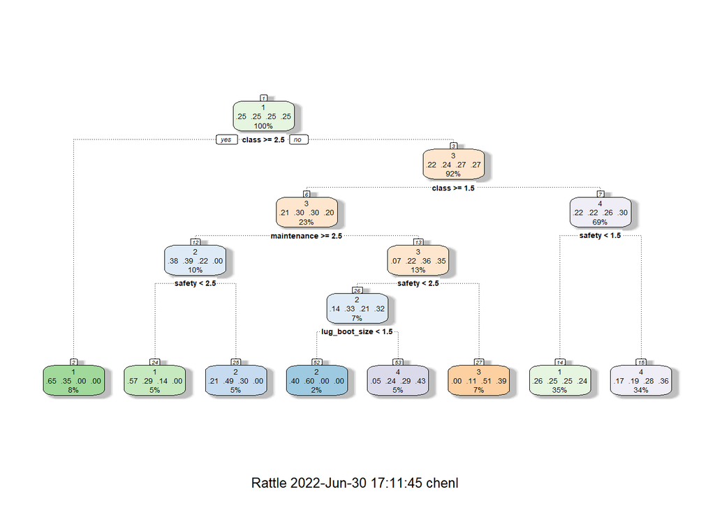

```r
# Building our Classification Tree Model with Training Data
set.seed(12345)
decisionTreeMod1 <- rpart(buying_price ~ ., data = trainData, method = "class")
fancyRpartPlot(decisionTreeMod1)
```

Next, we cross validate our Classification Tree Model with our validation data (validData), to determine the accuracy of this prediction model.

```r
# Cross Validating the Classification Tree Model with Validation Data
Prediction_Matrix_CT <- predict(decisionTreeMod1, validData, type = "class")
cmtree <- confusionMatrix(table(Prediction_Matrix_CT, validData$buying_price))
cmtree
```

```
## Confusion Matrix and Statistics
##
##
## Prediction_Matrix_CT  1  2  3  4
##                    1 68 56 41 36
##                    2 10 19  8  0
##                    3  0  3 12 10
##                    4 22 38 49 60
##
## Overall Statistics
##
##                Accuracy : 0.3681
##                  95% CI : (0.3225, 0.4155)
##     No Information Rate : 0.2685
##     P-Value [Acc > NIR] : 3.847e-06
##
##                   Kappa : 0.1669
##
##  Mcnemar's Test P-Value : < 2.2e-16
##
## Statistics by Class:
##
##                      Class: 1 Class: 2 Class: 3 Class: 4
## Sensitivity            0.6800  0.16379  0.10909   0.5660
## Specificity            0.5994  0.94304  0.95963   0.6656
## Pos Pred Value         0.3383  0.51351  0.48000   0.3550
## Neg Pred Value         0.8615  0.75443  0.75921   0.8251
## Prevalence             0.2315  0.26852  0.25463   0.2454
## Detection Rate         0.1574  0.04398  0.02778   0.1389
## Detection Prevalence   0.4653  0.08565  0.05787   0.3912
## Balanced Accuracy      0.6397  0.55342  0.53436   0.6158
```

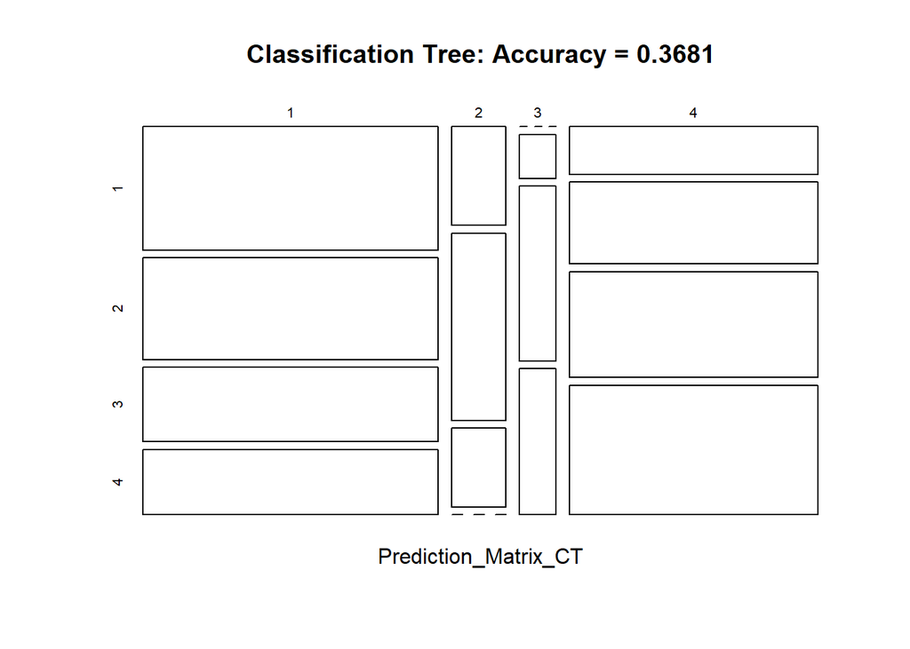

```r
# Plotting Results in a Matrix
plot(cmtree$table, col = cmtree$byClass,
     main = paste("Classification Tree: Accuracy =",
                  round(cmtree$overall['Accuracy'], 4)))
```

From the Classification Tree Matrix shown above, the accuracy of our Classification Tree Model is 0.3681. Therefore, its out-of-sample error is 0.6319.

## Prediction with Generalized Boosted Models

```r
# Building our Generalized Boosted Models with Training Data
set.seed(12345)
modGBM <- gbm(formula = as.factor(buying_price) ~ ., distribution = "gaussian",
              data = trainData, n.trees = 1000, interaction.depth = 3,
              shrinkage = 0.1, cv.folds = 5, n.cores = NULL, verbose = FALSE)
print(modGBM)
```

```
## gbm(formula = as.factor(buying_price) ~ ., distribution = "gaussian",
##     data = trainData, n.trees = 1000, interaction.depth = 3,
##     shrinkage = 0.1, cv.folds = 5, verbose = FALSE, n.cores = NULL)
## A gradient boosted model with gaussian loss function.
## 1000 iterations were performed.
## The best cross-validation iteration was 81.
## There were 6 predictors of which 6 had non-zero influence.
```

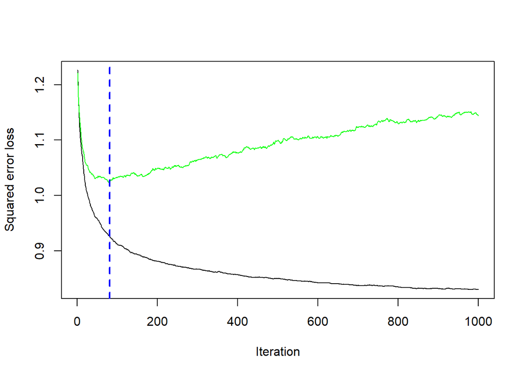

```
## [1] 81
```

```r
# Plotting our Generalized Boosted Models
gbm.perf(modGBM, method = "cv")
```

Next, we cross validate our Generalized Boosted Models with our validation data (validData), to determine the accuracy of this prediction model.

```r
# Cross Validating the Generalized Boosted Models with Validation Data
Prediction_Matrix_GBM <- round(predict(modGBM, newdata=validData, n.trees=1000), digits=0)
cmGBM <- confusionMatrix(table(Prediction_Matrix_GBM, validData$buying_price))
cmGBM
```

```
## Confusion Matrix and Statistics
##
##
## Prediction_Matrix_GBM  1  2  3  4
##                     1 29 14  0  0
##                     2 51 58 36 20
##                     3 20 44 68 59
##                     4  0  0  6 27
##
## Overall Statistics
##
##                Accuracy : 0.4213
##                  95% CI : (0.3743, 0.4694)
##     No Information Rate : 0.2685
##     P-Value [Acc > NIR] : 5.283e-12
##
##                   Kappa : 0.2212
##
##  Mcnemar's Test P-Value : NA
##
## Statistics by Class:
##
##                      Class: 1 Class: 2 Class: 3 Class: 4
## Sensitivity           0.29000   0.5000   0.6182  0.25472
## Specificity           0.95783   0.6614   0.6180  0.98160
## Pos Pred Value        0.67442   0.3515   0.3560  0.81818
## Neg Pred Value        0.81748   0.7828   0.8257  0.80201
## Prevalence            0.23148   0.2685   0.2546  0.24537
## Detection Rate        0.06713   0.1343   0.1574  0.06250
## Detection Prevalence  0.09954   0.3819   0.4421  0.07639
## Balanced Accuracy     0.62392   0.5807   0.6181  0.61816
```

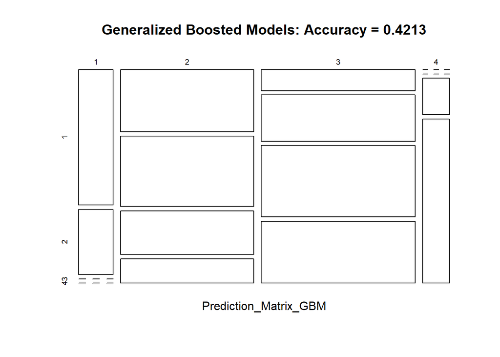

```r
# Plotting Results in a Matrix
plot(cmGBM$table, col = cmGBM$byClass,
     main = paste("Generalized Boosted Models: Accuracy =",
                  round(cmGBM$overall['Accuracy'], 4)))
```

From the Generalized Boosted Models Matrix shown above, the accuracy of our Generalized Boosted Models is 0.4213. Therefore, its out-of-sample error is 0.5787.

## Prediction with Random Decision Forests

```r
# Building our Random Decision Forests Model with Training Data
set.seed(12345)
controlRF <- trainControl(method="cv", number=10, verboseIter=FALSE)
modRF1 <- train(as.factor(buying_price) ~ ., data=trainData,
                method="rf", ntree=1000, trControl=controlRF)
modRF1$finalModel
```

```
##
## Call:
##  randomForest(x = x, y = y, ntree = 1000, mtry = min(param$mtry,      ncol(x)))
##                Type of random forest: classification
##                      Number of trees: 1000
## No. of variables tried at each split: 2
##
##         OOB estimate of  error rate: 83.1%
## Confusion matrix:
##    1  2  3  4 class.error
## 1 52 79 42 43   0.7592593
## 2 93 16 55 52   0.9259259
## 3 46 51 29 90   0.8657407
## 4 41 40 86 49   0.7731481
```

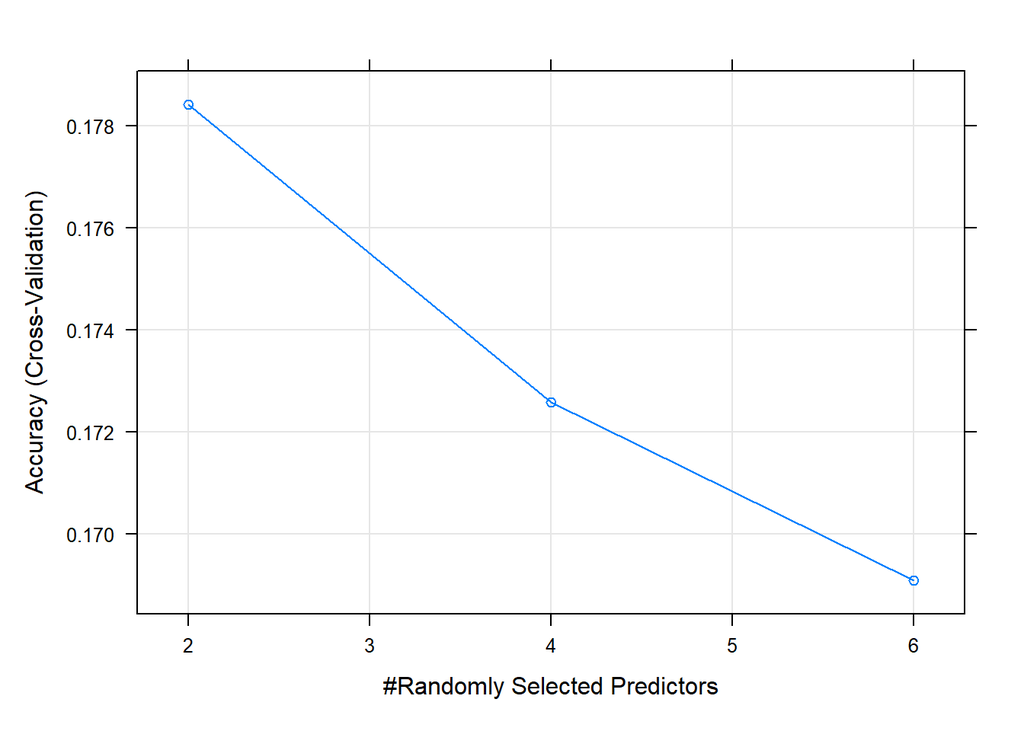

```r
# Plotting our Random Decision Forests Model
plot(modRF1)
```

Next, we cross validate our Random Decision Forests Model with our validation data (validData), to determine the accuracy of this prediction model.

```r
# Cross Validating the Random Decision Forests Model with Validation Data
Prediction_Matrix_RDF <- predict(modRF1, newdata=validData, type = "raw")
cmrf <- confusionMatrix(table(Prediction_Matrix_RDF, validData$buying_price))
cmrf
```

```
## Confusion Matrix and Statistics
##
##
## Prediction_Matrix_RDF  1  2  3  4
##                     1 65 28 13  9
##                     2 14 51  9 13
##                     3  9 20 66 18
##                     4 12 17 22 66
##
## Overall Statistics
##
##                Accuracy : 0.5741
##                  95% CI : (0.5259, 0.6212)
##     No Information Rate : 0.2685
##     P-Value [Acc > NIR] : < 2e-16
##
##                   Kappa : 0.433
##
##  Mcnemar's Test P-Value : 0.09062
##
## Statistics by Class:
##
##                      Class: 1 Class: 2 Class: 3 Class: 4
## Sensitivity            0.6500   0.4397   0.6000   0.6226
## Specificity            0.8494   0.8861   0.8540   0.8436
## Pos Pred Value         0.5652   0.5862   0.5841   0.5641
## Neg Pred Value         0.8896   0.8116   0.8621   0.8730
## Prevalence             0.2315   0.2685   0.2546   0.2454
## Detection Rate         0.1505   0.1181   0.1528   0.1528
## Detection Prevalence   0.2662   0.2014   0.2616   0.2708
## Balanced Accuracy      0.7497   0.6629   0.7270   0.7331
```

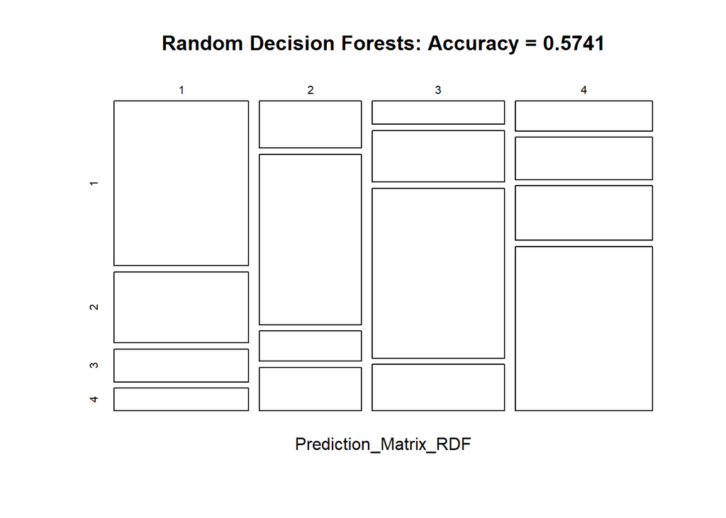

```r
# Plotting Results in a Matrix
plot(cmrf$table, col = cmrf$byClass,
     main = paste("Random Decision Forests: Accuracy =",
                  round(cmrf$overall['Accuracy'], 4)))
```

From the Random Decision Forests Matrix shown above, the accuracy of our Random Decision Forests Model is 0.5741. Therefore, its out-of-sample error is 0.4259.

## Best Prediction Model

The accuracy values of the 3 prediction models are as follow:

1. Classification Tree = 0.3681
2. Generalized Boosted Models = 0.4213
3. Random Decision Forests = 0.5741

From this comparison, we concluded that the Random Decision Forests Model is the best prediction model for our analysis.

```r
# Using our Random Decision Forests Model on Test Data
testData <- as.data.frame(lapply(testData, as.numeric))
Results <- predict(modRF1, newdata=testData, type = "raw")
testData[, "buying_price"] <- Results
write.csv(testData,'./car_result.csv', row.names = FALSE)
```

Our Random Forests Model was able to predict the buying price of the car for our test case (testData).

The generated output (Results) contains this information and it has been added back into the test data accordingly. You may refer to the new test data file (car_result.csv) for more information.